# Tidy Data Tutorial

Sonya Hua

December 2, 2017

source: https://www.jstatsoft.org/article/view/v059i10

#### In tidy data:

1. Each variable forms a column.
2. Each observation forms a row.
3. Each type of observational unit forms a table.

Real datasets can, and often do, violate the three precepts of tidy data in almost every way imaginable. While occasionally you do get a dataset that you can start analyzing immediately, this is the exception, not the rule. This section describes the ???ve most common problems with messy datasets, along with their remedies: - Column headers are values, not variable names.

- Multiple variables are stored in one column.
- Variables are stored in both rows and columns.
- Multiple types of observational units are stored in the same table.
- A single observational unit is stored in multiple tables

### Preparation for Tutorial

First, let’s install Ludvig’s split chunk [add-in](http://ludvigolsen.dk/splitchunk-rstudio-addin/?lang=en) so we can easily split chunks and add markdown in between.

```r
# R add-in for splitting chunks

#install.packages("devtools")
library(devtools)
devtools::install_github("LudvigOlsen/splitChunk")
```

**xtable:** Converts an R object to an xtable object, which can then be printed as a LaTeX or HTML table.

```r
options(stringsAsFactors = FALSE)

library("stringr")
library("reshape2")
```

```r
library("plyr")

read.fwf2 <- function(path, cols) {
  raw_stations <- readLines(path)
  stations <- data.frame(matrix(ncol = 0, nrow = length(raw_stations)))

  for(i in 1:nrow(cols)) {
    field <- cols[i, ]
    stations[[field$name]] <- str_trim(str_sub(raw_stations, field$start, field$end))
  }
  stations[stations == ""] <- NA
  stations[] <- lapply(stations, type.convert, as.is = TRUE)

  stations
}

# Change defaults for xtable to be more attractive
# Inspired by: http://cameron.bracken.bz/sweave-xtable-booktabs
library("xtable")
xtable <- function(x, file = "", ..., rownames = FALSE) {
  table <- xtable::xtable(x, ...)
  print(table, floating = FALSE, hline.after = NULL,
    add.to.row = list(pos = list(-1,0, nrow(x)),
    command = c('\\toprule\n ','\\midrule\n  ','\\bottomrule\n')),
    include.rownames = rownames, NA.string = "---",
    file = file,
    comment = FALSE, timestamp = FALSE
  )
}
```

### Simulate Data

```r
####################################################################
## 2. Defining tidy data
####################################################################

set.seed(1014)

preg <- matrix(c(NA, sample(20, 5)), ncol = 2, byrow = TRUE)
colnames(preg) <- paste0("treatment", c("a", "b"))
rownames(preg) <- c("John Smith", "Jane Doe", "Mary Johnson")

xtable(preg, "preg-raw-1.tex", rownames = TRUE, align = "lrr")
xtable(t(preg), "preg-raw-2.tex", rownames = TRUE, align = "lrrr")
preg
```

```
##              treatmenta treatmentb
## John Smith           NA          2
## Jane Doe             16         11
## Mary Johnson          3          1
```

```r
# Make tidy version

(pregm <- melt(preg, id = "name"))
```

```
##           Var1       Var2 value
## 1   John Smith treatmenta    NA
## 2     Jane Doe treatmenta    16
## 3 Mary Johnson treatmenta     3
## 4   John Smith treatmentb     2
## 5     Jane Doe treatmentb    11
## 6 Mary Johnson treatmentb     1
```

```r
# rename the columns
names(pregm) <- c("name", "trt", "result")
pregm
```

```
##           name        trt result
## 1   John Smith treatmenta     NA
## 2     Jane Doe treatmenta     16
## 3 Mary Johnson treatmenta      3
## 4   John Smith treatmentb      2
## 5     Jane Doe treatmentb     11
## 6 Mary Johnson treatmentb      1
```

```r
# Sub "treatment" with ""
pregm$trt <- gsub("treatment", "", pregm$trt)
pregm
```

```
##           name trt result
## 1   John Smith   a     NA
## 2     Jane Doe   a     16
## 3 Mary Johnson   a      3
## 4   John Smith   b      2
## 5     Jane Doe   b     11
## 6 Mary Johnson   b      1
```

```r
#install.packages("lubridate")
library(lubridate)
xtable(pregm, "preg-tidy.tex")
pregm
```

```
##           name trt result
## 1   John Smith   a     NA
## 2     Jane Doe   a     16
## 3 Mary Johnson   a      3
## 4   John Smith   b      2
## 5     Jane Doe   b     11
## 6 Mary Johnson   b      1
```

```r
####################################################################
## 3. Tidying messy datasets
####################################################################
## 3.1 Column headers are values, not variable names: toy example
####################################################################

df <- data.frame(row = LETTERS[1:3], a = 1:3, b = 4:6, c = 7:9)
xtable(df, "melt-raw.tex")
df
```

```
##   row a b c
## 1   A 1 4 7
## 2   B 2 5 8
## 3   C 3 6 9
```

Melting a data frame by an id column puts all the column variables into 1 column and values into another

```r
dfm <- melt(df, id = "row")
names(dfm)[2] <- "column"
xtable(dfm, "melt-output.tex")
dfm
```

```
##   row column value
## 1   A      a     1
## 2   B      a     2
## 3   C      a     3
## 4   A      b     4
## 5   B      b     5
## 6   C      b     6
## 7   A      c     7
## 8   B      c     8
## 9   C      c     9
```

```r
####################################################################
## 3.1 Column headers are values, not variable names: Pew dataset
####################################################################

library("foreign")

# Data from http://pewforum.org/Datasets/Dataset-Download.aspx

# Load data -----------------------------------------------------------------

pew <- read.spss("pew.sav")
```

```
## re-encoding from CP1252
```

```r
pew <- as.data.frame(pew)
str(pew)
```

```
## 'data.frame':    35556 obs. of  135 variables:
##  $ weight  : num  4.51 2.1 1.28 1.36 1.59 ...
##  $ psraid  : num  1e+07 1e+07 1e+07 1e+07 1e+07 ...
##  $ int_date: num  50807 50807 50807 50807 50807 ...
##  $ lang    : Factor w/ 2 levels "English","Spanish": 1 1 1 1 1 1 1 1 1 1 ...
##  $ type    : Factor w/ 2 levels "RDD","Callback": 1 1 1 1 1 1 1 1 1 1 ...
##  $ cregion : Factor w/ 4 levels "Northeast","Midwest",..: 1 1 1 1 1 1 1 1 3 3 ...
##  $ state   : Factor w/ 51 levels "Alabama","Alaska",..: 7 20 20 20 33 33 33 39 11 10 ...
##  $ usr     : Factor w/ 3 levels "Rural","Suburban",..: 2 1 1 1 3 3 3 3 3 2 ...
##  $ usr1    : Factor w/ 3 levels "Urban","Suburban",..: 2 3 3 3 1 1 1 1 1 2 ...
##  $ form    : Factor w/ 2 levels "Form A","Form B": 1 2 1 2 1 1 1 1 1 2 ...
##  $ density3: Factor w/ 6 levels "Lowest","2","3",..: 4 1 2 2 5 5 5 5 2 2 ...
##  $ q1      : Factor w/ 3 levels "Satisfied","Dissatisfied",..: 1 1 1 2 2 2 2 2 2 2 ...
##  $ q1a     : Factor w/ 3 levels "Very","Somewhat",..: 1 1 2 1 1 1 1 2 2 1 ...
##  $ q2      : Factor w/ 3 levels "Satisfied","Dissatisfied",..: 1 1 1 1 1 2 1 2 1 1 ...
```

[output cut: 86 more lines]

```r
# Select 3 columns as a df
religion <- pew[c("q16", "reltrad", "income")]
head(religion)
```

```
##                       q16                           reltrad
## 1             Protestant   Evangelical Protestant Churches
## 2             Protestant      Mainline Protestant Churches
## 3             Protestant      Mainline Protestant Churches
## 4  Nothing in particular                      Unaffiliated
## 5       Jewish (Judaism)                            Jewish
## 6       Jewish (Judaism)                            Jewish
##                 income
## 1 75 to under $100,000
## 2  20 to under $30,000
## 3  30 to under $40,000
## 4    Less than $10,000
## 5  50 to under $75,000
## 6  20 to under $30,000
```

```r
# Correct to character type
religion$reltrad <- as.character(religion$reltrad)

# Replace some of the values
head(religion$reltrad, 25)
```

```
##  [1] " Evangelical Protestant Churches "
##  [2] " Mainline Protestant Churches "
##  [3] " Mainline Protestant Churches "
##  [4] " Unaffiliated "
##  [5] " Jewish "
##  [6] " Jewish "
##  [7] " Jewish "
##  [8] " Mainline Protestant Churches "
##  [9] " Mainline Protestant Churches "
## [10] " Dont know/refused (no information on religious affiliation) "
## [11] " Mainline Protestant Churches "
## [12] " Mainline Protestant Churches "
## [13] " Mainline Protestant Churches "
## [14] " Evangelical Protestant Churches "
## [15] " Evangelical Protestant Churches "
## [16] " Evangelical Protestant Churches "
## [17] " Evangelical Protestant Churches "
## [18] " Other Faiths "
## [19] " Mainline Protestant Churches "
## [20] " Historically Black Protestant Churches "
## [21] " Mainline Protestant Churches "
## [22] " Evangelical Protestant Churches "
## [23] " Evangelical Protestant Churches "
## [24] " Mainline Protestant Churches "
## [25] " Unaffiliated "
```

```r
religion$reltrad <- str_replace(religion$reltrad, " Churches", "")
head(religion$reltrad, 25)
```

```
##  [1] " Evangelical Protestant "
##  [2] " Mainline Protestant "
##  [3] " Mainline Protestant "
##  [4] " Unaffiliated "
##  [5] " Jewish "
##  [6] " Jewish "
##  [7] " Jewish "
##  [8] " Mainline Protestant "
##  [9] " Mainline Protestant "
## [10] " Dont know/refused (no information on religious affiliation) "
## [11] " Mainline Protestant "
## [12] " Mainline Protestant "
## [13] " Mainline Protestant "
## [14] " Evangelical Protestant "
## [15] " Evangelical Protestant "
## [16] " Evangelical Protestant "
## [17] " Evangelical Protestant "
## [18] " Other Faiths "
## [19] " Mainline Protestant "
## [20] " Historically Black Protestant "
## [21] " Mainline Protestant "
## [22] " Evangelical Protestant "
## [23] " Evangelical Protestant "
## [24] " Mainline Protestant "
## [25] " Unaffiliated "
```

```r
# Clean up some of the labels
religion$reltrad <- str_replace(religion$reltrad, " Protestant", " Prot")
religion$reltrad[religion$q16 == " Atheist (do not believe in God) "] <- "Atheist"
religion$reltrad[religion$q16 == " Agnostic (not sure if there is a God) "] <- "Agnostic"
religion$reltrad <- str_trim(religion$reltrad)
religion$reltrad <- str_replace_all(religion$reltrad, " \\(.*?\\)", "")

head(religion$reltrad, 25)
```

```
##  [1] "Evangelical Prot"        "Mainline Prot"
##  [3] "Mainline Prot"           "Unaffiliated"
##  [5] "Jewish"                  "Jewish"
##  [7] "Jewish"                  "Mainline Prot"
##  [9] "Mainline Prot"           "Dont know/refused"
## [11] "Mainline Prot"           "Mainline Prot"
## [13] "Mainline Prot"           "Evangelical Prot"
## [15] "Evangelical Prot"        "Evangelical Prot"
## [17] "Evangelical Prot"        "Other Faiths"
## [19] "Mainline Prot"           "Historically Black Prot"
## [21] "Mainline Prot"           "Evangelical Prot"
## [23] "Evangelical Prot"        "Mainline Prot"
## [25] "Unaffiliated"
```

```r
str(religion)
```

```
## 'data.frame':    35556 obs. of  3 variables:
##  $ q16    : Factor w/ 65 levels " Protestant ",..: 1 1 1 11 5 5 5 1 1 54 ...
##  $ reltrad: chr  "Evangelical Prot" "Mainline Prot" "Mainline Prot" "Unaffiliated" ...
##  $ income : Factor w/ 10 levels "Less than $10,000",..: 7 3 4 1 6 3 9 5 4 4 ...
```

```r
religion$income <- c(`Less than $10,000` = "<$10k", `10 to under $20,000` = "$10--20k",
  `20 to under $30,000` = "$20--30k", `30 to under $40,000` = "$30--40k", `40 to under $50,000` = "$40--50k",
  `50 to under $75,000` = "$50--75k", `75 to under $100,000` = "$75--100k", `100 to under $150,000` = "$100--150k",
  `$150,000 or more` = ">150k", `Don't know/Refused (VOL)` = "Don't know/refused")[religion$income]
head(religion$income)
```

```
## [1] "$75--100k" "$20--30k"  "$30--40k"  "<$10k"     "$50--75k"  "$20--30k"
```

```r
# convert income values into factors
religion$income <- factor(religion$income, levels = c("<$10k", "$10--20k", "$20--30k",
  "$30--40k", "$40--50k", "$50--75k", "$75--100k", "$100--150k", ">150k", "Don't know/refused"))

counts <- count(religion, c("reltrad", "income"))
names(counts)[1] <- "religion"

xtable(counts[1:10, ], file = "pew-clean.tex")
head(counts)
```

```
##   religion   income freq
## 1 Agnostic    <$10k   27
## 2 Agnostic $10--20k   34
## 3 Agnostic $20--30k   60
## 4 Agnostic $30--40k   81
## 5 Agnostic $40--50k   76
## 6 Agnostic $50--75k  137
```

```r
# Convert into the form in which I originally saw it -------------------------

raw <- dcast(counts, religion ~ income)
xtable(raw[1:10, 1:7], file = "pew-raw.tex")
head(raw)
```

```
##                    religion <$10k $10--20k $20--30k $30--40k $40--50k
## 1                  Agnostic    27       34       60       81       76
## 2                   Atheist    12       27       37       52       35
## 3                  Buddhist    27       21       30       34       33
## 4                  Catholic   418      617      732      670      638
## 5 Dont know/refused    15       14       15       11       10
## 6          Evangelical Prot   575      869     1064      982      881
##   $50--75k $75--100k $100--150k >150k Don't know/refused
## 1      137       122        109    84                 96
## 2       70        73         59    74                 76
## 3       58        62         39    53                 54
## 4     1116       949        792   633               1489
## 5       35        21         17    18                116
## 6     1486       949        723   414               1529
```

### 3.2. Multiple variables stored in one column

```r
####################################################################
## 3.2 Multiple variables stored in one column: TB dataset
####################################################################

# Load -----------------------------------------------------------------------
raw <- read.csv("tb.csv", na.strings = "")
head(raw)
```

```
##   iso2 year new_sp new_sp_m04 new_sp_m514 new_sp_m014 new_sp_m1524
## 1   AD 1989     NA         NA          NA          NA           NA
## 2   AD 1990     NA         NA          NA          NA           NA
## 3   AD 1991     NA         NA          NA          NA           NA
## 4   AD 1992     NA         NA          NA          NA           NA
## 5   AD 1993     15         NA          NA          NA           NA
## 6   AD 1994     24         NA          NA          NA           NA
##   new_sp_m2534 new_sp_m3544 new_sp_m4554 new_sp_m5564 new_sp_m65 new_sp_mu
## 1           NA           NA           NA           NA         NA        NA
## 2           NA           NA           NA           NA         NA        NA
## 3           NA           NA           NA           NA         NA        NA
## 4           NA           NA           NA           NA         NA        NA
## 5           NA           NA           NA           NA         NA        NA
## 6           NA           NA           NA           NA         NA        NA
##   new_sp_f04 new_sp_f514 new_sp_f014 new_sp_f1524 new_sp_f2534
## 1         NA          NA          NA           NA           NA
## 2         NA          NA          NA           NA           NA
## 3         NA          NA          NA           NA           NA
## 4         NA          NA          NA           NA           NA
## 5         NA          NA          NA           NA           NA
## 6         NA          NA          NA           NA           NA
##   new_sp_f3544 new_sp_f4554 new_sp_f5564 new_sp_f65 new_sp_fu
## 1           NA           NA           NA         NA        NA
## 2           NA           NA           NA         NA        NA
## 3           NA           NA           NA         NA        NA
## 4           NA           NA           NA         NA        NA
## 5           NA           NA           NA         NA        NA
## 6           NA           NA           NA         NA        NA
```

```r
raw$new_sp <- NULL
raw <- subset(raw, year == 2000)
names(raw)[1] <- "country"

names(raw) <- str_replace(names(raw), "new_sp_", "")
raw$m04 <- NULL
raw$m514 <- NULL
raw$f04 <- NULL
raw$f514 <- NULL

xtable(raw[1:10, 1:11], file = "tb-raw.tex")
head(raw)
```

```
##     country year m014 m1524 m2534 m3544 m4554 m5564 m65 mu f014 f1524
## 11       AD 2000    0     0     1     0     0     0   0 NA   NA    NA
## 37       AE 2000    2     4     4     6     5    12  10 NA    3    16
## 61       AF 2000   52   228   183   149   129    94  80 NA   93   414
## 88       AG 2000    0     0     0     0     0     0   1 NA    1     1
## 137      AL 2000    2    19    21    14    24    19  16 NA    3    11
## 166      AM 2000    2   152   130   131    63    26  21 NA    1    24
##     f2534 f3544 f4554 f5564 f65 fu
## 11     NA    NA    NA    NA  NA NA
## 37      1     3     0     0   4 NA
## 61    565   339   205    99  36 NA
## 88      1     0     0     0   0 NA
## 137    10     8     8     5  11 NA
## 166    27    24     8     8   4 NA
```

```r
# Melt -----------------------------------------------------------------------

clean <- melt(raw, id = c("country", "year"), na.rm = TRUE)
names(clean)[3] <- "column"
names(clean)[4] <- "cases"
clean <- arrange(clean, country, column, year)
head(clean)
```

```
##   country year column cases
## 1      AD 2000   m014     0
## 2      AD 2000  m1524     0
## 3      AD 2000  m2534     1
## 4      AD 2000  m3544     0
## 5      AD 2000  m4554     0
## 6      AD 2000  m5564     0
```

str_sub will recycle all arguments to be the same length as the longest argument. If any arguments are of length 0, the output will be a zero length character vector.

```r
xtable(clean[1:15, ], file = "tb-clean-1.tex")

# Break up variable in to sex and age ----------------------------------------

clean$sex <- str_sub(clean$column, 1, 1)

ages <- c(`04` = "0--4", `514` = "5--14", `014` = "0--14", `1524` = "15--24", `2534` = "25--34",
  `3544` = "35--44", `4554` = "45--54", `5564` = "55--64", `65` = "65+", u = NA)

clean$age <- factor(ages[str_sub(clean$column, 2)], levels = ages)

clean <- clean[c("country", "year", "sex", "age", "cases")]

xtable(clean[1:15, ], file = "tb-clean-2.tex")
head(clean)
```

```
##   country year sex    age cases
## 1      AD 2000   m  0--14     0
## 2      AD 2000   m 15--24     0
## 3      AD 2000   m 25--34     1
## 4      AD 2000   m 35--44     0
## 5      AD 2000   m 45--54     0
## 6      AD 2000   m 55--64     0
```

### 3.3 Variables are stored in both rows and columns

```r
####################################################################
## 3.3 Variables are stored in both rows and columns: weather dataset
####################################################################

# Define format for fixed width file
cols <- data.frame(name = c("id", "year", "month", "element"), start = c(1, 12, 16,
  18), end = c(11, 15, 17, 21))

head(cols)
```

```
##      name start end
## 1      id     1  11
## 2    year    12  15
## 3   month    16  17
## 4 element    18  21
```

```r
names <- str_c(c("value", "mflag", "qflag", "sflag"), rep(1:31, each = 4), sep = "_")
starts <- cumsum(c(22, rep(c(5, 1, 1, 1), 31)))
starts <- starts[-length(starts)]
ends <- c(starts[-1], starts[length(starts)] + 1) - 1

values <- data.frame(name = names, start = starts, end = ends)
cols <- rbind(cols, values)

# Load data and subset to small example
raw <- read.fwf2("weather.txt", cols)
raw <- subset(raw, year == 2010 & element %in% c("TMIN", "TMAX"))
raw <- raw[, c(1:4, which(str_detect(names(raw), "value")))]
raw$id <- str_c(str_sub(raw$id, 1, 2), str_sub(raw$id, -5, -1))

names(raw)[-(1:4)] <- str_c("d", 1:31)
raw[raw == -9999] <- NA
raw[-(1:4)] <- raw[-(1:4)]/10
rownames(raw) <- NULL
raw$element <- tolower(raw$element)

xtable(raw[1:10, 1:12], file = "weather-raw.tex", digits = 1)
head(raw)
```

```
##        id year month element d1   d2   d3 d4   d5 d6 d7 d8 d9  d10  d11
## 1 MX17004 2010     1    tmax NA   NA   NA NA   NA NA NA NA NA   NA   NA
## 2 MX17004 2010     1    tmin NA   NA   NA NA   NA NA NA NA NA   NA   NA
## 3 MX17004 2010     2    tmax NA 27.3 24.1 NA   NA NA NA NA NA   NA 29.7
## 4 MX17004 2010     2    tmin NA 14.4 14.4 NA   NA NA NA NA NA   NA 13.4
## 5 MX17004 2010     3    tmax NA   NA   NA NA 32.1 NA NA NA NA 34.5   NA
## 6 MX17004 2010     3    tmin NA   NA   NA NA 14.2 NA NA NA NA 16.8   NA
##   d12 d13 d14 d15  d16 d17 d18 d19 d20 d21 d22  d23 d24 d25 d26 d27 d28
## 1  NA  NA  NA  NA   NA  NA  NA  NA  NA  NA  NA   NA  NA  NA  NA  NA  NA
## 2  NA  NA  NA  NA   NA  NA  NA  NA  NA  NA  NA   NA  NA  NA  NA  NA  NA
## 3  NA  NA  NA  NA   NA  NA  NA  NA  NA  NA  NA 29.9  NA  NA  NA  NA  NA
## 4  NA  NA  NA  NA   NA  NA  NA  NA  NA  NA  NA 10.7  NA  NA  NA  NA  NA
## 5  NA  NA  NA  NA 31.1  NA  NA  NA  NA  NA  NA   NA  NA  NA  NA  NA  NA
## 6  NA  NA  NA  NA 17.6  NA  NA  NA  NA  NA  NA   NA  NA  NA  NA  NA  NA
##   d29  d30 d31
## 1  NA 27.8  NA
## 2  NA 14.5  NA
## 3  NA   NA  NA
## 4  NA   NA  NA
## 5  NA   NA  NA
## 6  NA   NA  NA
```

```r
# Melt and tidy

clean1 <- melt(raw, id = 1:4, na.rm = TRUE)
clean1$day <- as.integer(str_replace(clean1$variable, "d", ""))
clean1$date <- as.Date(ISOdate(clean1$year, clean1$month, clean1$day))

clean1 <- clean1[c("id", "date", "element", "value")]
clean1 <- arrange(clean1, date, element)
clean1$date <- as.character(clean1$date)  # work around xtable bug
xtable(clean1[1:10, ], file = "weather-clean-1.tex", digits = 1)
head(clean1)
```

```
##        id       date element value
## 1 MX17004 2010-01-30    tmax  27.8
## 2 MX17004 2010-01-30    tmin  14.5
## 3 MX17004 2010-02-02    tmax  27.3
## 4 MX17004 2010-02-02    tmin  14.4
## 5 MX17004 2010-02-03    tmax  24.1
## 6 MX17004 2010-02-03    tmin  14.4
```

To arrange by element, cast a molten df into an array or df. Fixing the issue with the type of observation requires the cast, or unstack, operation. This performs the inverse of melting by rotating the element variable back out into the columns

Below is a tidy weather dataset. Each row represents the meteorological measurements for a single day. There are two measured variables, minimum (tmin) and maximum (tmax) temperature; all other variables are ???xed.

```r
# Cast

clean2 <- dcast(clean1, ... ~ element)
xtable(clean2[1:10, ], file = "weather-clean-2.tex", digits = 1)

head(clean2)
```

```
##        id       date tmax tmin
## 1 MX17004 2010-01-30 27.8 14.5
## 2 MX17004 2010-02-02 27.3 14.4
## 3 MX17004 2010-02-03 24.1 14.4
## 4 MX17004 2010-02-11 29.7 13.4
## 5 MX17004 2010-02-23 29.9 10.7
## 6 MX17004 2010-03-05 32.1 14.2
```

### 3.4 Multiple Types in one table

Datasets often involve values collected at multiple levels, on di???erent types of observational units. During tidying, each type of observational unit should be stored in its own table. This is closely related to the idea of database normalization, where each fact is expressed in only one place. If this is not done, it is possible for inconsistencies to occur.

The Billboard dataset described below actually contains observations on two types of observational units: the song and its rank in each week. This manifests itself through the duplication of facts about the song: artist and time are repeated for every song in each week.

```r
####################################################################
## 3.4 Multiple types in one table: Billboard dataset
####################################################################

library("lubridate")

raw <- read.csv("billboard.csv")

raw <- raw[, c("year", "artist.inverted", "track", "time", "date.entered", "x1st.week",
  "x2nd.week", "x3rd.week", "x4th.week", "x5th.week", "x6th.week", "x7th.week",
  "x8th.week", "x9th.week", "x10th.week", "x11th.week", "x12th.week", "x13th.week",
  "x14th.week", "x15th.week", "x16th.week", "x17th.week", "x18th.week", "x19th.week",
  "x20th.week", "x21st.week", "x22nd.week", "x23rd.week", "x24th.week", "x25th.week",
  "x26th.week", "x27th.week", "x28th.week", "x29th.week", "x30th.week", "x31st.week",
  "x32nd.week", "x33rd.week", "x34th.week", "x35th.week", "x36th.week", "x37th.week",
  "x38th.week", "x39th.week", "x40th.week", "x41st.week", "x42nd.week", "x43rd.week",
  "x44th.week", "x45th.week", "x46th.week", "x47th.week", "x48th.week", "x49th.week",
  "x50th.week", "x51st.week", "x52nd.week", "x53rd.week", "x54th.week", "x55th.week",
  "x56th.week", "x57th.week", "x58th.week", "x59th.week", "x60th.week", "x61st.week",
  "x62nd.week", "x63rd.week", "x64th.week", "x65th.week", "x66th.week", "x67th.week",
  "x68th.week", "x69th.week", "x70th.week", "x71st.week", "x72nd.week", "x73rd.week",
  "x74th.week", "x75th.week", "x76th.week")]

names(raw)[2] <- "artist"

raw$artist <- iconv(raw$artist, "MAC", "ASCII//translit")
raw$track <- str_replace(raw$track, " \\(.*?\\)", "")
names(raw)[-(1:5)] <- str_c("wk", 1:76)
raw <- arrange(raw, year, artist, track)

long_name <- nchar(raw$track) > 20
raw$track[long_name] <- paste0(substr(raw$track[long_name], 0, 20), "...")


xtable(raw[c(1:3, 6:10), 1:8], "billboard-raw.tex")

head(raw,25)
```

```
##    year               artist                   track time date.entered wk1
## 1  2000                2 Pac          Baby Don't Cry 4:22   2000-02-26  87
## 2  2000              2Ge+her The Hardest Part Of ... 3:15   2000-09-02  91
## 3  2000         3 Doors Down              Kryptonite 3:53   2000-04-08  81
## 4  2000         3 Doors Down                   Loser 4:24   2000-10-21  76
## 5  2000             504 Boyz           Wobble Wobble 3:35   2000-04-15  57
## 6  2000                  98? Give Me Just One Nig... 3:24   2000-08-19  51
## 7  2000              A*Teens           Dancing Queen 3:44   2000-07-08  97
## 8  2000              Aaliyah           I Don't Wanna 4:15   2000-01-29  84
## 9  2000              Aaliyah               Try Again 4:03   2000-03-18  59
## 10 2000       Adams, Yolanda           Open My Heart 5:30   2000-08-26  76
## 11 2000        Adkins, Trace                    More 3:05   2000-04-29  84
## 12 2000  Aguilera, Christina       Come On Over Baby 3:38   2000-08-05  57
## 13 2000  Aguilera, Christina           I Turn To You 4:00   2000-04-15  50
## 14 2000  Aguilera, Christina       What A Girl Wants 3:18   1999-11-27  71
```

[output cut: 167 more lines]

The Billboard dataset needs to be broken down into two datasets: a song dataset which stores artist, song name and time, and a ranking dataset which gives the rank of the song in each week.

```r
clean <- melt(raw, id = 1:5, na.rm = TRUE)
clean$week <- as.integer(str_replace_all(clean$variable, "[^0-9]+", ""))
clean$variable <- NULL

clean$date.entered <- ymd(clean$date.entered)
clean$date <- clean$date.entered + weeks(clean$week - 1)
clean$date.entered <- NULL
clean <- rename(clean, c(value = "rank"))
clean <- arrange(clean, year, artist, track, time, week)
clean <- clean[c("year", "artist", "time", "track", "date", "week", "rank")]

clean_out <- mutate(clean, date = as.character(date))
xtable(clean_out[1:15, ], "billboard-clean.tex")
head(clean, 25)
```

```
##    year       artist time                   track       date week rank
## 1  2000        2 Pac 4:22          Baby Don't Cry 2000-02-26    1   87
## 2  2000        2 Pac 4:22          Baby Don't Cry 2000-03-04    2   82
## 3  2000        2 Pac 4:22          Baby Don't Cry 2000-03-11    3   72
## 4  2000        2 Pac 4:22          Baby Don't Cry 2000-03-18    4   77
## 5  2000        2 Pac 4:22          Baby Don't Cry 2000-03-25    5   87
## 6  2000        2 Pac 4:22          Baby Don't Cry 2000-04-01    6   94
## 7  2000        2 Pac 4:22          Baby Don't Cry 2000-04-08    7   99
## 8  2000      2Ge+her 3:15 The Hardest Part Of ... 2000-09-02    1   91
## 9  2000      2Ge+her 3:15 The Hardest Part Of ... 2000-09-09    2   87
## 10 2000      2Ge+her 3:15 The Hardest Part Of ... 2000-09-16    3   92
## 11 2000 3 Doors Down 3:53              Kryptonite 2000-04-08    1   81
## 12 2000 3 Doors Down 3:53              Kryptonite 2000-04-15    2   70
## 13 2000 3 Doors Down 3:53              Kryptonite 2000-04-22    3   68
## 14 2000 3 Doors Down 3:53              Kryptonite 2000-04-29    4   67
## 15 2000 3 Doors Down 3:53              Kryptonite 2000-05-06    5   66
## 16 2000 3 Doors Down 3:53              Kryptonite 2000-05-13    6   57
## 17 2000 3 Doors Down 3:53              Kryptonite 2000-05-20    7   54
## 18 2000 3 Doors Down 3:53              Kryptonite 2000-05-27    8   53
## 19 2000 3 Doors Down 3:53              Kryptonite 2000-06-03    9   51
## 20 2000 3 Doors Down 3:53              Kryptonite 2000-06-10   10   51
## 21 2000 3 Doors Down 3:53              Kryptonite 2000-06-17   11   51
## 22 2000 3 Doors Down 3:53              Kryptonite 2000-06-24   12   51
## 23 2000 3 Doors Down 3:53              Kryptonite 2000-07-01   13   47
## 24 2000 3 Doors Down 3:53              Kryptonite 2000-07-08   14   44
## 25 2000 3 Doors Down 3:53              Kryptonite 2000-07-15   15   38
```

Normalization is useful for tidying and eliminating inconsistencies. However, there are few data analysis tools that work directly with relational data, so analysis usually also requires denormalization or merging the datasets back into one table.

```r
# Normalization --------------------------------------------------------------

song <- unrowname(unique(clean[c("artist", "track", "time")]))
song$id <- 1:nrow(song)

narrow <- song[1:15, c("id", "artist", "track", "time")]
xtable(narrow, "billboard-song.tex")

rank <- join(clean, song, match = "first")
rank <- rank[c("id", "date", "rank")]
rank$date <- as.character(rank$date)
xtable(rank[1:15, ], "billboard-rank.tex")
head(rank,25)
```

```
##    id       date rank
## 1   1 2000-02-26   87
## 2   1 2000-03-04   82
## 3   1 2000-03-11   72
## 4   1 2000-03-18   77
## 5   1 2000-03-25   87
## 6   1 2000-04-01   94
## 7   1 2000-04-08   99
## 8   2 2000-09-02   91
## 9   2 2000-09-09   87
## 10  2 2000-09-16   92
## 11  3 2000-04-08   81
## 12  3 2000-04-15   70
## 13  3 2000-04-22   68
## 14  3 2000-04-29   67
## 15  3 2000-05-06   66
## 16  3 2000-05-13   57
## 17  3 2000-05-20   54
## 18  3 2000-05-27   53
## 19  3 2000-06-03   51
## 20  3 2000-06-10   51
## 21  3 2000-06-17   51
## 22  3 2000-06-24   51
## 23  3 2000-07-01   47
## 24  3 2000-07-08   44
## 25  3 2000-07-15   38
```

### Case Study: Morality Data from Mexico

```r
####################################################################
## 5. Case study
####################################################################

library("ggplot2")
library("MASS")

if (!file.exists("deaths.rds")) {
  ## from https://github.com/hadley/mexico-mortality/raw/master/deaths/deaths08.csv.bz2
  deaths <- read.csv("deaths08.csv.bz2")
  unlink("deaths08.csv.bz2")
  deaths$hod[deaths$hod == 99] <- NA
  deaths$hod[deaths$hod == 24] <- 0
  deaths$hod[deaths$hod == 0] <- NA
  deaths$hod <- as.integer(deaths$hod)
  deaths <- arrange(deaths, yod, mod, dod, hod, cod)
  deaths <- deaths[c("yod", "mod", "dod", "hod", "cod")]
  saveRDS(deaths, "deaths.rds")
}

deaths <- readRDS("deaths.rds")
head(deaths, 25)
```

```
##    yod mod dod hod cod
## 1    0   0   0  NA E14
## 2    0   0   0  NA E46
## 3    0   0   0  NA I21
## 4    0   0   0  NA K70
## 5    0   0   0  NA P21
## 6    0   0   0  NA Q89
## 7    0   0   0  NA R99
## 8    0   0   0  NA R99
## 9    0   0   0  NA R99
## 10   0   0   0  NA R99
## 11   0   0   0  NA R99
## 12   0   0   0  NA R99
## 13   0   0   0  NA R99
## 14   0   0   0  NA R99
## 15   0   0   0  NA R99
## 16   0   0   0  NA R99
## 17   0   0   0  NA R99
## 18   0   0   0  NA R99
## 19   0   0   0  NA V09
## 20   0   0   0  NA W34
## 21   0   0   0  NA W34
## 22   0   0   0  NA X59
## 23   0   0   0  NA X59
## 24   0   0   0  NA X59
## 25   0   0   0  NA X59
```

```r
ok <- subset(deaths, yod == 2008 & mod != 0 & dod != 0)
xtable(ok[c(1, 1:14 * 2000), c("yod", "mod", "dod", "hod", "cod")], "raw.tex")
head(ok)
```

```
##        yod mod dod hod cod
## 11938 2008   1   1   1 B20
## 11939 2008   1   1   1 B22
## 11940 2008   1   1   1 C18
## 11941 2008   1   1   1 C34
## 11942 2008   1   1   1 C50
## 11943 2008   1   1   1 C50
```

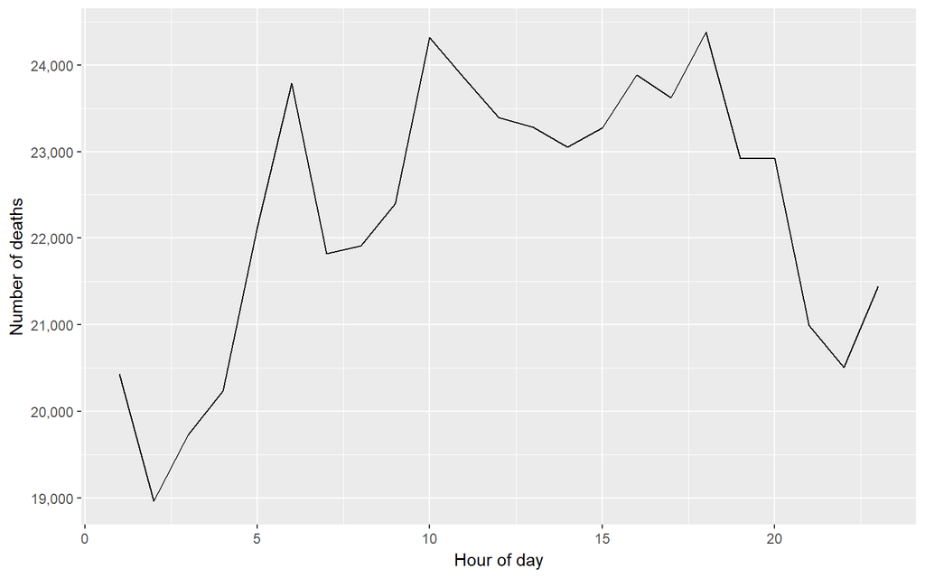

```r
codes <- read.csv("icd-main.csv")
codes$disease <- sapply(codes$disease, function(x) str_c(strwrap(x, width = 30),
  collapse = "\n"))
names(codes)[1] <- "cod"
codes <- codes[!duplicated(codes$cod), ]

# Display overall hourly deaths
hod_all <- subset(count(deaths, "hod"), !is.na(hod))
qplot(hod, freq, data = hod_all, geom = "line") + scale_y_continuous("Number of deaths",
  labels = function(x) format(x, big.mark = ",")) + xlab("Hour of day")
```

```r
ggsave("overall.pdf", width = 10, height = 6)
```

To achieve our goal of ???nding unusual temporal patterns, we do the following. First, we count the number of deaths in each hour (hod) for each cause (cod) with the tidy count function.

Then we remove missing (and hence uninformative for our purpose) values with subset.

To provide informative labels for disease, we next join the dataset to the codes dataset, connected by the cod variable. This adds a new variable, disease.

```r
# Count deaths per hour, per disease
hod2 <- count(deaths, c("cod", "hod"))
hod2 <- subset(hod2, !is.na(hod))
hod2 <- join(hod2, codes)
hod2 <- ddply(hod2, "cod", transform, prop = freq/sum(freq))

# Compare to overall abundance
overall <- ddply(hod2, "hod", summarise, freq_all = sum(freq))
overall <- mutate(overall, prop_all = freq_all/sum(freq_all))

hod2 <- join(overall, hod2, by = "hod")

# Pick better subset of rows to show
cods <- join(arrange(count(deaths, "cod"), desc(freq)), codes)
mutate(tail(subset(cods, freq > 100), 30), disease = str_sub(disease, 1, 30))
```

```
##     cod freq                         disease
## 321 V04  119 Pedestrian injured in\ncollisio
## 322 Q23  118 Congenital malformations of\nao
## 323 C51  117     Malignant neoplasm of vulva
## 324 P91  116 Other disturbances of\ncerebral
## 325 X44  116 Accidental poisoning by and\nex
## 326 J68  115 Respiratory conditions due to\n
## 327 D35  114 Benign neoplasm of other and\nu
## 328 Y57  114 Adverse effects in\ntherapeutic
## 329 I83  113 Varicose veins of lower\nextrem
## 330 J06  113 Acute upper respiratory\ninfect
## 331 E84  112                 Cystic fibrosis
## 332 Q22  112 Congenital malformations of\npu
## 333 I72  111                  Other aneurysm
## 334 V05  108 Pedestrian injured in\ncollisio
```

[output cut: 16 more lines]

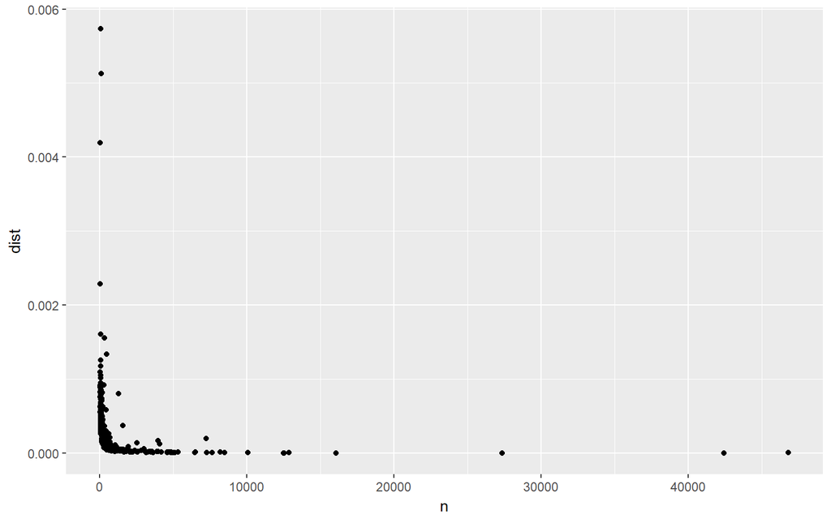

```r
hod3 <- subset(hod2, cod %in% c("I21", "N18", "E84", "B16") & hod >= 8 & hod <= 12)[1:15,
  c("hod", "cod", "disease", "freq", "prop", "freq_all", "prop_all")]

xtable(hod3[c("hod", "cod", "freq")], "counts.tex")
xtable(hod3[c("disease")], "counts-disease.tex")
xtable(hod3[5], "counts-prop.tex")
xtable(hod3[6:7], "counts-all.tex")

devi <- ddply(hod2, "cod", summarise, n = sum(freq), dist = mean((prop - prop_all)^2))
devi <- subset(devi, n > 50)

# Find outliers
xlog10 <- scale_x_log10(breaks = c(100, 1000, 10000), labels = c(100, 1000, 10000),
  minor_breaks = log10(outer(1:9, 10^(1:5), "*")))
ylog10 <- scale_y_log10(breaks = 10^-c(3, 4, 5), labels = c("0.001", "0.0001", "0.00001"),
  minor_breaks = log10(outer(1:9, 10^-(3:6), "*")))

qplot(n, dist, data = devi)
```

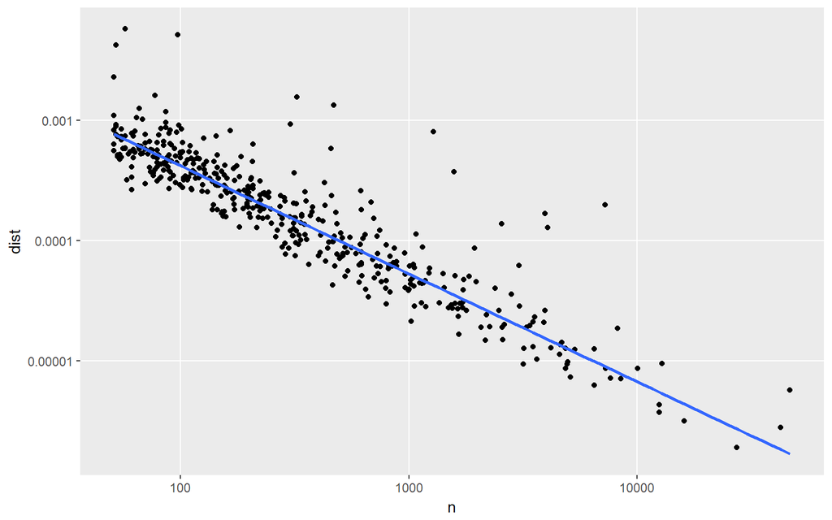

```r
ggsave("n-dist-raw.pdf", width = 6, height = 6)
qplot(n, dist, data = devi) + geom_smooth(method = "rlm", se = FALSE) + xlog10 + ylog10
```

```r
ggsave("n-dist-log.pdf", width = 6, height = 6)
devi$resid <- resid(rlm(log(dist) ~ log(n), data = devi))
coef(rlm(log(dist) ~ log(n), data = devi))
```

```
## (Intercept)      log(n)
##  -3.6471353  -0.8970054
```

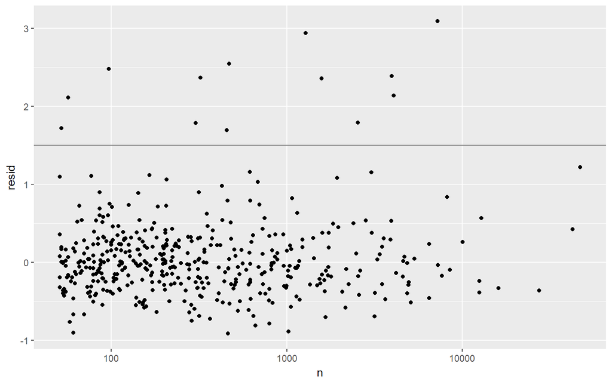

```r
ggplot(devi, aes(n, resid)) + geom_hline(yintercept = 1.5, colour = "grey50") + geom_point() +
  xlog10
```

```r
ggsave("n-dist-resid.pdf", width = 6, height = 6)

unusual <- subset(devi, resid > 1.5)
hod_unusual_big <- match_df(hod2, subset(unusual, n > 350))
```

```
## Matching on: cod
```

```r
hod_unusual_sml <- match_df(hod2, subset(unusual, n <= 350))
```

```
## Matching on: cod
```

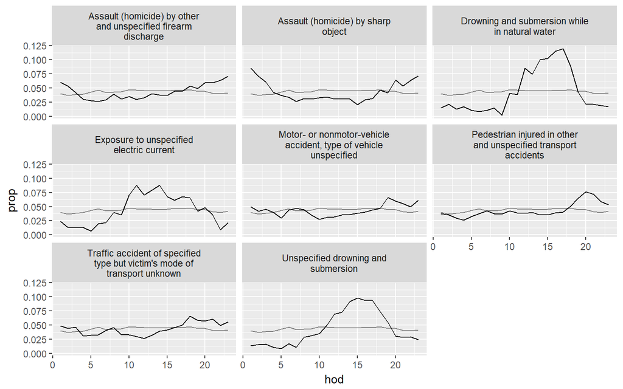

```r
# Visualize unusual causes of death
ggplot(hod_unusual_big, aes(hod, prop)) + geom_line(aes(y = prop_all), data = overall,
  colour = "grey50") + geom_line() + facet_wrap(~disease, ncol = 3)
```

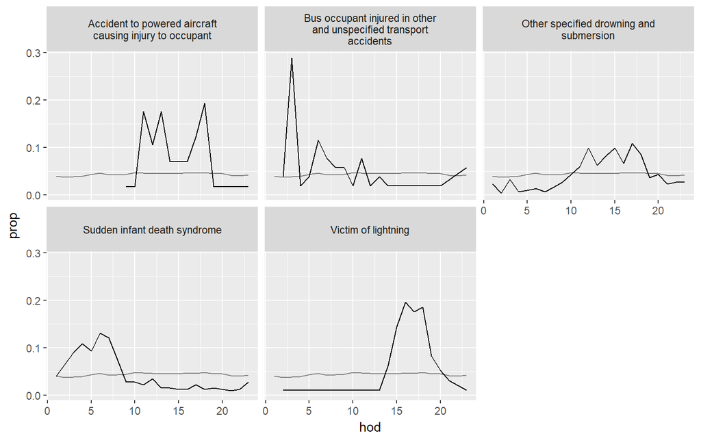

```r
ggsave("unusual-big.pdf", width = 8, height = 6)
last_plot() %+% hod_unusual_sml
```

```r
ggsave("unusual-sml.pdf", width = 8, height = 4)
```